# PDA_NYC_BIKES

2022-04-19

1.1 citi bikes are a company that operate in new york city who provide a service of publicly accessible bicycles from stations which can then be returned to a simmilar station at a different location makeing it an ideal mode of transport for fast, eco freindly, inexpensive one way travel.

1.2 this analysis will analyse the target demographic for citi bikes to advartise and cater to to maximise their frequent customer satisfaction. aswell as identify peak times of usage for the bikes wherein more resources will be required for an efficant service.

1.7 the data is processed before visualisation to make it easier to understand, the days of the week are ordered chronologicaly and impossible ages are removed to prevent the integrity of the data being compromised. the age of the person is calculated from the birth year and the year of the reccord.

1.4 the average age for a user is between 25 and 35, while an anomalous stand out group does seem to exist, the gender imporbability seen here calls into the question the reliability of this data for these factors.

1.6 it is also possible that a system default has been set for unidentified users. this should be removed if it is the case as unlabled data is more usefull when classified as unknown rather than skewing the remainder of the valid data.

all bike usage over time

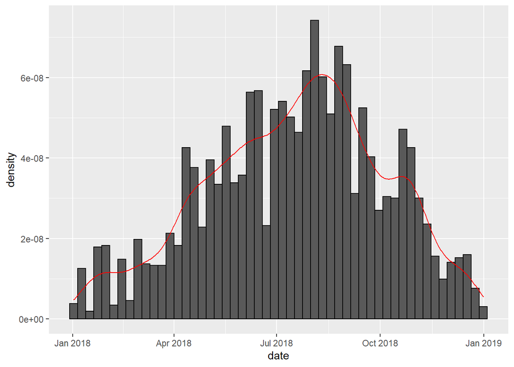

this yearly diagram of service use demonstrates a seasonal pattern, however more data will be required to confirm this theory. current marketing and business decisions should be conducted with expecte high use in july and august and limmited use over the winter

peak bike usage times

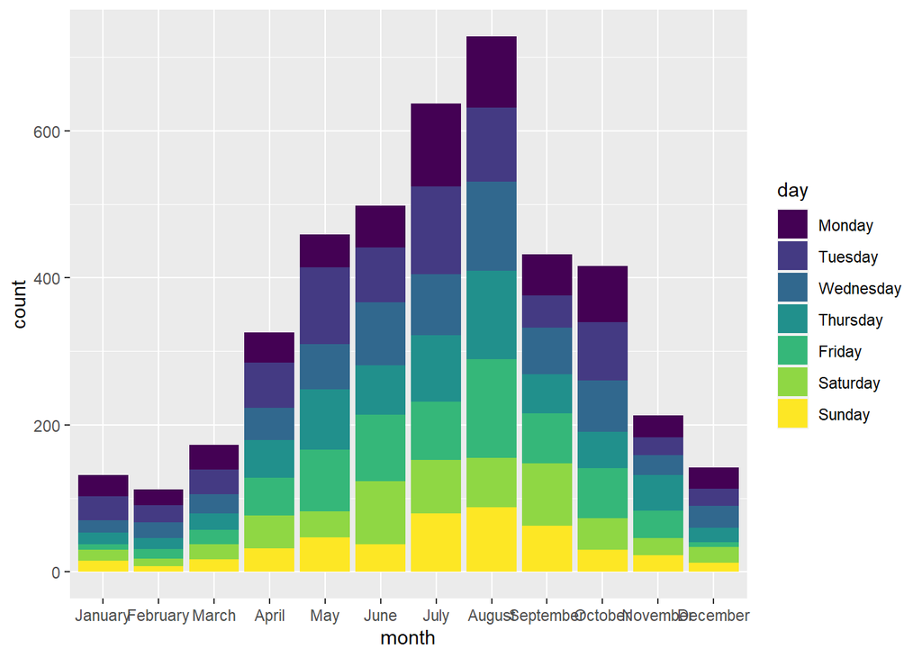

the highest usage for the service is dureing the months of july and august likely due to the good weather. the most popular days for usage however are weekdays which possibly suggests there is a market for commuters using this service for transport to work

bike usage by age and gender

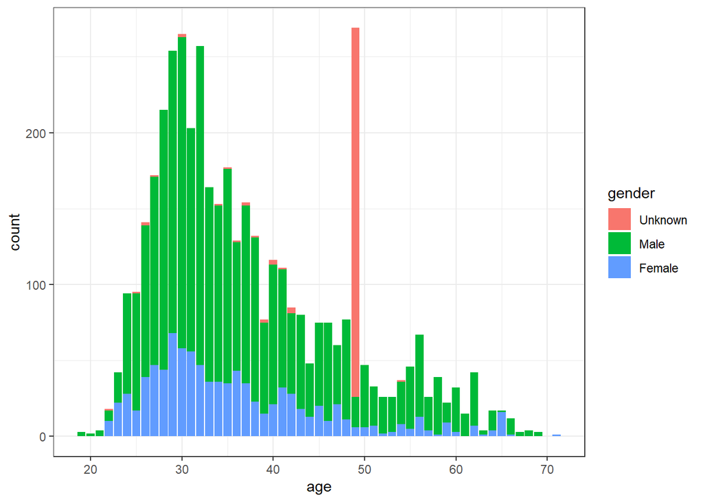

[interactive chart not shown]

this plot shows the geographical position between the stations. there are 52 active stations in the area covered by the data. the density of stations near jersey city is greater and so the possibility for inefficiancy increases

future work on this dataset should include an analysis on which stations are most used and the distances of each trip using the station locations coordinates. this can also be broken down into the average distance covered by individual bikes. this information can be used to rotate bikes between high use and low use stations. or position the bikes at the stations such that the bikes of low use become more available to distruibute the bikes usage.